# Chapter 5

## Conceptual

### Excercise 2a

$\Pr ({x_1} \ne {x_j}|{x_1}) = \frac{1}{n}\sum\nolimits_{j = 1}^n {I({x_1} \ne {x_j})} = \frac{{n - 1}}{n}$

### Excercise 2b

$\Pr ({x_2} \ne {x_j}|{x_2}) = \frac{1}{n}\sum\nolimits_{j = 1}^n {I({x_2} \ne {x_j})} = \frac{{n - 1}}{n}$

### Excercise 2c

The probability that *j* th observation is not in the bootstrap sample is equivalent to the probability of drawing $n$ times, with each time the observation was not the *j* th observation.

Each of the $n$ observations was drawn with probability of $\frac{{n - 1}}{n}$ if it was not the *j* th observation from the original sample. Its *n* th power indicates that we have drawn *n* such bootstrap samples, therefore we have $\Pr (x \ne {x_j}|x) = {(\frac{{n - 1}}{n})^n}$

### Excercise 2d

Substituting $n = 5$ to above equation, we have $\Pr (x \ne {x_j}|x) = {(\frac{{5 - 1}}{5})^5} \approx 0.33$ Therefore, the probability that the *j* th observation is in the bootstrap sample is $1 - \Pr (x \ne {x_j}|x) = 1 - 0.33 = 0.67$

### Excercise 2e

Substituting $n = 100$ to above equation, we have $\Pr (x \ne {x_j}|x) = {(\frac{{100 - 1}}{{100}})^{100}} \approx 0.37$ Therefore, the probability that the *j* th observation is in the bootstrap sample is $1 - \Pr (x \ne {x_j}|x) = 1 - 0.37 = 0.63$

### Excercise 2f

Substituting $n = 10000$ to above equation, we have $\Pr (x \ne {x_j}|x) = {(\frac{{10000 - 1}}{{10000}})^{10000}} \approx 0.37$ Therefore, the probability that the *j* th observation is in the bootstrap sample is $1 - \Pr (x \ne {x_j}|x) = 1 - 0.37 = 0.63$

### Excercise 2g

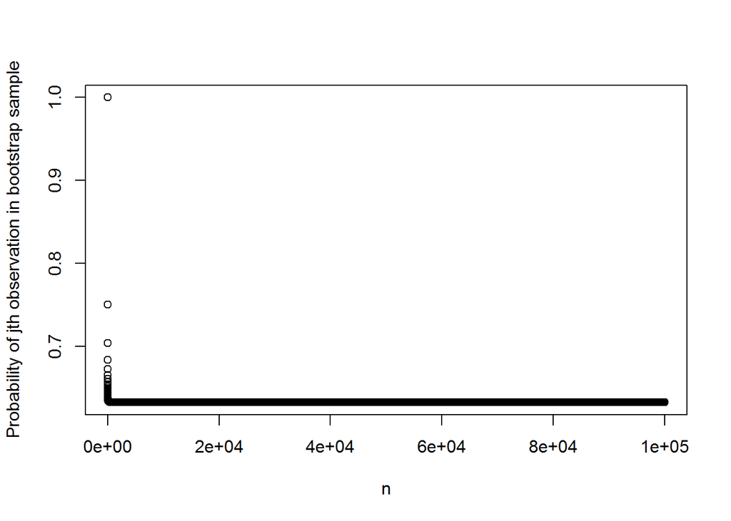

```r
probs = rep(0, 1e+05)
for ( n in 1:1e+05) {
  probs[n] = 1 - ((n-1)/n)^n
}
plot(1:1e+05, probs, xlab = "n", ylab = "Probability of jth observation in bootstrap sample")
```

After $n = 100$, the probability of jth observation in bootstrap sample remains approximately 0.63 and doesn’t change as the n increases.

### Excercise 2h

```r
store = rep(NA, 1e+4)
for ( i in 1:1e+4) {
  store[i] = sum(sample(1:100, rep = T) == 4) > 0
}
mean(store)
```

```
## [1] 0.6276
```

The result obtained above indicates that the probability of *n bootstrap samples* of size 100 which contain *j* th observation is equivalent to the probability of *one bootstrap sample* of size n that contains *j* th observation.

### Excercise 3a

K-fold cross-validation is implemented by averaging the perfomance of k measurements, each of which uses $(k-1)/k$ data as training set and $1/k$ data as validation set from the randomly shuffled samples. After splitting the randomly shuffled samples into k non-overlapping groups, group of validation set is chosen sequentially for each of the k measurements.

### Excercise 3b

1. K-fold cross-validation shows the advantage of unbiased evaluation comparing to the validation set approach (since validation set apparoach uses only half of the original samples as training set), provided that K is 5 or 10 rather than close to n.
2. Leave-one-out cross-validation (LOOCV) shows more unbaised result, however will suffer from high-variance of the model compraing to the K-fold cross-validation.

### Excercise 4

1. Sample with replacement on the entire dataet.
2. Fit the sample with our statistical learning method.
3. Predict given a particular value of $X$ and store the prediction value into an array `predictions`.
4. Repeat (1)-(3) for many times (like 10,000), for each time, we store the prediction value into `predictions`.
5. In order to assess the spread degree of predictions, calculate standard deviation by `std(predictions)`.

## Applied

### Excercise 5a

```r
library(ISLR)
attach(Default)
glm.fit = glm(default~income+balance, data = Default, family=binomial)
summary(glm.fit)
```

```
##
## Call:
## glm(formula = default ~ income + balance, family = binomial,
##     data = Default)
##
## Deviance Residuals:
##     Min       1Q   Median       3Q      Max
## -2.4725  -0.1444  -0.0574  -0.0211   3.7245
##
## Coefficients:
##               Estimate Std. Error z value Pr(>|z|)
## (Intercept) -1.154e+01  4.348e-01 -26.545  < 2e-16 ***
## income       2.081e-05  4.985e-06   4.174 2.99e-05 ***
## balance      5.647e-03  2.274e-04  24.836  < 2e-16 ***
## ---
## Signif. codes:  0 '***' 0.001 '**' 0.01 '*' 0.05 '.' 0.1 ' ' 1
##
## (Dispersion parameter for binomial family taken to be 1)
##
##     Null deviance: 2920.6  on 9999  degrees of freedom
## Residual deviance: 1579.0  on 9997  degrees of freedom
## AIC: 1585
##
## Number of Fisher Scoring iterations: 8
```

### Excercise 5b

```r
set.seed(1)
train_ind = sample(nrow(Default), nrow(Default) / 2, replace = T)
train = rep(F, nrow(Default))
train[train_ind] = T
test.X = Default[-train_ind, ]
test.Y = default[!train]
```

```r
glm.fit = glm(default~income+balance, subset = train, family = binomial)
summary(glm.fit)
```

```
##
## Call:
## glm(formula = default ~ income + balance, family = binomial,
##     subset = train)
##
## Deviance Residuals:
##     Min       1Q   Median       3Q      Max
## -2.4282  -0.1504  -0.0622  -0.0226   3.6789
##
## Coefficients:
##               Estimate Std. Error z value Pr(>|z|)
## (Intercept) -1.126e+01  6.607e-01 -17.048   <2e-16 ***
## income       1.956e-05  7.690e-06   2.544    0.011 *
## balance      5.510e-03  3.513e-04  15.684   <2e-16 ***
## ---
## Signif. codes:  0 '***' 0.001 '**' 0.01 '*' 0.05 '.' 0.1 ' ' 1
##
## (Dispersion parameter for binomial family taken to be 1)
##
##     Null deviance: 1171.66  on 3970  degrees of freedom
## Residual deviance:  640.82  on 3968  degrees of freedom
## AIC: 646.82
##
## Number of Fisher Scoring iterations: 8
```

```r
glm.probs = predict(glm.fit, test.X, type = "response")
contrasts(default)
```

```
##     Yes
## No    0
## Yes   1
```

```r
glm.pred = rep("No", length(glm.probs))
glm.pred[glm.probs > .5] = "Yes"
```

```r
table(glm.pred, test.Y)
```

```
##         test.Y
## glm.pred   No  Yes
##      No  5807  135
##      Yes   23   64
```

```r
mean(glm.pred != test.Y)
```

```
## [1] 0.02620667
```

### Excercise 5c

```r
train_ind = sample(nrow(Default), nrow(Default) / 2, replace = T)
train = rep(F, nrow(Default))
train[train_ind] = T
test.X = Default[-train_ind, ]
test.Y = default[!train]
glm.fit = glm(default~income+balance, subset = train, family = binomial)
glm.probs = predict(glm.fit, test.X, type = "response")
glm.pred = rep("No", length(glm.probs))
glm.pred[glm.probs > .5] = "Yes"
summary(glm.fit)
```

```
##
## Call:
## glm(formula = default ~ income + balance, family = binomial,
##     subset = train)
##
## Deviance Residuals:
##     Min       1Q   Median       3Q      Max
## -2.4202  -0.1515  -0.0642  -0.0256   3.6417
##
## Coefficients:
##               Estimate Std. Error z value Pr(>|z|)
## (Intercept) -1.118e+01  6.706e-01 -16.677  < 2e-16 ***
## income       2.620e-05  8.072e-06   3.246  0.00117 **
## balance      5.328e-03  3.462e-04  15.388  < 2e-16 ***
## ---
## Signif. codes:  0 '***' 0.001 '**' 0.01 '*' 0.05 '.' 0.1 ' ' 1
##
## (Dispersion parameter for binomial family taken to be 1)
##
##     Null deviance: 1107.29  on 3918  degrees of freedom
## Residual deviance:  625.17  on 3916  degrees of freedom
## AIC: 631.17
##
## Number of Fisher Scoring iterations: 8
```

```r
mean(glm.pred != test.Y)
```

```
## [1] 0.02647591
```

```r
train_ind = sample(nrow(Default), nrow(Default) / 2, replace = T)
train = rep(F, nrow(Default))
train[train_ind] = T
test.X = Default[-train_ind, ]
test.Y = default[!train]
glm.fit = glm(default~income+balance, subset = train, family = binomial)
glm.probs = predict(glm.fit, test.X, type = "response")
glm.pred = rep("No", length(glm.probs))
glm.pred[glm.probs > .5] = "Yes"
summary(glm.fit)
```

[output not shown]

```r
mean(glm.pred != test.Y)
```

```
## [1] 0.02647591
```

```r
train_ind = sample(nrow(Default), nrow(Default) / 2, replace = T)
train = rep(F, nrow(Default))
train[train_ind] = T
test.X = Default[-train_ind, ]
test.Y = default[!train]
glm.fit = glm(default~income+balance, subset = train, family = binomial)
glm.probs = predict(glm.fit, test.X, type = "response")
glm.pred = rep("No", length(glm.probs))
glm.pred[glm.probs > .5] = "Yes"
summary(glm.fit)
```

```
##
## Call:
## glm(formula = default ~ income + balance, family = binomial,
##     subset = train)
##
## Deviance Residuals:
##     Min       1Q   Median       3Q      Max
## -2.2680  -0.1404  -0.0522  -0.0190   3.3667
##
## Coefficients:
##               Estimate Std. Error z value Pr(>|z|)
## (Intercept) -1.189e+01  7.128e-01 -16.683  < 2e-16 ***
## income       2.206e-05  7.868e-06   2.804  0.00504 **
## balance      5.842e-03  3.738e-04  15.628  < 2e-16 ***
## ---
## Signif. codes:  0 '***' 0.001 '**' 0.01 '*' 0.05 '.' 0.1 ' ' 1
##
## (Dispersion parameter for binomial family taken to be 1)
##
##     Null deviance: 1148.22  on 3922  degrees of freedom
## Residual deviance:  605.95  on 3920  degrees of freedom
## AIC: 611.95
##
## Number of Fisher Scoring iterations: 8
```

```r
mean(glm.pred != test.Y)
```

```
## [1] 0.02731611
```

For all three iterations, the validation set error are almost identical.

### Excercise 5d

```r
train_ind = sample(nrow(Default), nrow(Default) / 2, replace = T)
train = rep(F, nrow(Default))
train[train_ind] = T
test.X = Default[-train_ind, ]
test.Y = default[!train]
glm.fit = glm(default~income+balance+student, subset = train, family = binomial)
glm.probs = predict(glm.fit, test.X, type = "response")
glm.pred = rep("No", length(glm.probs))
glm.pred[glm.probs > .5] = "Yes"
summary(glm.fit)
```

```
##
## Call:
## glm(formula = default ~ income + balance + student, family = binomial,
##     subset = train)
##
## Deviance Residuals:
##     Min       1Q   Median       3Q      Max
## -1.9031  -0.1334  -0.0483  -0.0161   3.7467
##
## Coefficients:
##               Estimate Std. Error z value Pr(>|z|)
## (Intercept) -1.136e+01  8.085e-01 -14.053   <2e-16 ***
## income      -2.497e-07  1.305e-05  -0.019   0.9847
## balance      6.230e-03  3.930e-04  15.851   <2e-16 ***
## studentYes  -7.613e-01  3.822e-01  -1.992   0.0464 *
## ---
## Signif. codes:  0 '***' 0.001 '**' 0.01 '*' 0.05 '.' 0.1 ' ' 1
##
## (Dispersion parameter for binomial family taken to be 1)
##
##     Null deviance: 1239.90  on 3908  degrees of freedom
## Residual deviance:  629.02  on 3905  degrees of freedom
## AIC: 637.02
##
## Number of Fisher Scoring iterations: 8
```

```r
mean(glm.pred != test.Y)
```

```
## [1] 0.0252832
```

### Excercise 6a

```r
glm.fit = glm(default~income+balance, family = binomial)
summary(glm.fit)$coef
```

```
##                  Estimate   Std. Error    z value      Pr(>|z|)
## (Intercept) -1.154047e+01 4.347564e-01 -26.544680 2.958355e-155
## income       2.080898e-05 4.985167e-06   4.174178  2.990638e-05
## balance      5.647103e-03 2.273731e-04  24.836280 3.638120e-136
```

### Excercise 6b

```r
boot.fn = function(data, index) {
  coefficients(glm(default~income+balance, data = data, subset = index, family = binomial))
}
```

### Excercise 6c

```r
library(boot)
set.seed(1)
boot(Default, boot.fn, 1000)
```

```
##
## ORDINARY NONPARAMETRIC BOOTSTRAP
##
##
## Call:
## boot(data = Default, statistic = boot.fn, R = 1000)
##
##
## Bootstrap Statistics :
##          original        bias     std. error
## t1* -1.154047e+01 -8.008379e-03 4.239273e-01
## t2*  2.080898e-05  5.870933e-08 4.582525e-06
## t3*  5.647103e-03  2.299970e-06 2.267955e-04
```

### Excercise 6d

The estimated standard errors obtained using the glm() function are almost identical to the results using bootstrap function.

```r
# clean up
rm(list = ls())
```

### Excercise 7a

```r
library(ISLR)
attach(Weekly)
glm.fit = glm(Direction~Lag1+Lag2, family = binomial)
summary(glm.fit)$coef
```

```
##                Estimate Std. Error   z value     Pr(>|z|)
## (Intercept)  0.22122405 0.06146572  3.599145 0.0003192652
## Lag1        -0.03872222 0.02621658 -1.477013 0.1396722362
## Lag2         0.06024830 0.02654589  2.269590 0.0232324586
```

### Excercise 7b

```r
glm.fit = glm(Direction~Lag1+Lag2, subset = 2:nrow(Weekly), family = binomial)
summary(glm.fit)$coef
```

```
##                Estimate Std. Error   z value     Pr(>|z|)
## (Intercept)  0.22324305 0.06149894  3.630031 0.0002833875
## Lag1        -0.03843317 0.02621860 -1.465874 0.1426825151
## Lag2         0.06084763 0.02656088  2.290874 0.0219707105
```

### Excercise 7c

```r
prob = predict(glm.fit, Weekly[1, ], type = "response")
contrasts(Direction)
```

```
##      Up
## Down  0
## Up    1
```

```r
pred = "Down"
if (prob > .5) pred = "Up"
if (pred == Direction[1] ) {
  print("Correct prediction")
} else {
  print("Incorrect prediction")
}
```

```
## [1] "Incorrect prediction"
```

### Excercise 7d

```r
glm.probs = rep(NA, nrow(Weekly))
for ( i in 1:nrow(Weekly) ) {
  glm.fit = glm(Direction~Lag1+Lag2, subset = (1:nrow(Weekly))[-i], family = binomial)
  glm.probs[i] = predict(glm.fit, Weekly[i, ], type = "response")
}
```

### Excercise 7e

```r
glm.pred = rep("Down", nrow(Weekly))
glm.pred[glm.probs > .5] = "Up"
table(glm.pred, Direction)
```

```
##         Direction
## glm.pred Down  Up
##     Down   34  40
##     Up    450 565
```

```r
mean(glm.pred != Direction)
```

```
## [1] 0.4499541
```

### Excercise 8a

```r
set.seed(1)
y = rnorm(100) # non-sense
x = rnorm(100)
y = x - 2 * x^2 + rnorm(100)
```

$n = 100$ and $p = 2$. The equation form: $y = {\beta _0} + {\beta _1}{x_1} + {\beta _2}{x_2} + {\sigma ^2}$ Here $\begin{array}{l} {\beta _0} = 0\\ {\beta _1} = 1,{x_1} = x\\ {\beta _2} = - 2,{x_2} = {x^2}\\ {\sigma ^2} \sim N(0,1) \end{array}$ i.e, $y = x - 2{x^2} + {\sigma ^2}$

### Excercise 8b

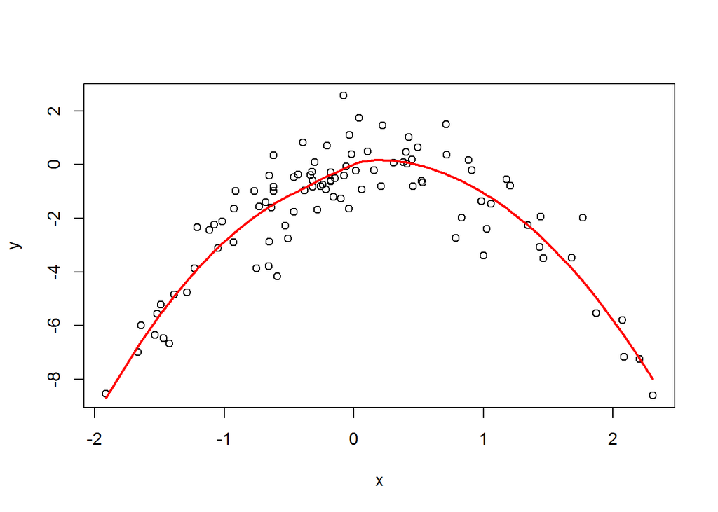

```r
plot(y ~ x)
j = order(x)
lo = loess(y ~ x)
lines(x[j], predict(lo)[j], col = 'red', lwd = 2)
```

A parabola curve was fitted with added noise.

### Excercise 8c

```r
library(boot)
set.seed(1)
x = rnorm(100)
y = x - 2 * x^2 + rnorm(100)
```

```r
glm.fit = glm(y ~ x)
cv.err = cv.glm(data.frame(x, y), glm.fit)
cv.err$delta
```

```
## [1] 7.288162 7.284744
```

```r
glm.fit = glm(y ~ poly(x, 2))
cv.err = cv.glm(data.frame(x, y), glm.fit)
cv.err$delta
```

```
## [1] 0.9374236 0.9371789
```

```r
glm.fit = glm(y ~ poly(x, 3))
cv.err = cv.glm(data.frame(x, y), glm.fit)
cv.err$delta
```

```
## [1] 0.9566218 0.9562538
```

```r
glm.fit = glm(y ~ poly(x, 4))
cv.err = cv.glm(data.frame(x, y), glm.fit)
cv.err$delta
```

```
## [1] 0.9539049 0.9534453
```

### Excercise 8d

```r
set.seed(2)
x = rnorm(100)
y = x - 2 * x^2 + rnorm(100)
cv.error = rep(0, 5)
for ( i in 1:5 ) {
  glm.fit = glm(y ~ poly(x, i))
  cv.error[i] = cv.glm(data.frame(x, y), glm.fit)$delta[1]
}
cv.error
```

```
## [1] 9.858301 1.004410 1.018030 1.035601 1.057525
```

The results comparing to *8(c)* are not the same, because using different seed results in different data of $X$ and $Y$.

### Excercise 8e

The second model in *8(c)* had the smallest LOOCV error.

Yes, the results were obtained in expectation because the true relationship of $X$ and $Y$ are quadratic.

### Excercise 8f

```r
set.seed(1)
x = rnorm(100)
y = x - 2 * x^2 + rnorm(100)
cv.error = rep(0, 5)
for ( i in 1:5 ) {
  glm.fit = glm(y ~ poly(x, i))
  print(summary(glm.fit))
  cv.error[i] = cv.glm(data.frame(x, y), glm.fit)$delta[1]
}
```

```
##
## Call:
## glm(formula = y ~ poly(x, i))
##
## Deviance Residuals:
##     Min       1Q   Median       3Q      Max
## -9.5161  -0.6800   0.6812   1.5491   3.8183
##
## Coefficients:
##             Estimate Std. Error t value Pr(>|t|)
## (Intercept)   -1.550      0.260  -5.961 3.95e-08 ***
## poly(x, i)     6.189      2.600   2.380   0.0192 *
## ---
## Signif. codes:  0 '***' 0.001 '**' 0.01 '*' 0.05 '.' 0.1 ' ' 1
##
## (Dispersion parameter for gaussian family taken to be 6.760719)
##
##     Null deviance: 700.85  on 99  degrees of freedom
## Residual deviance: 662.55  on 98  degrees of freedom
## AIC: 478.88
##
## Number of Fisher Scoring iterations: 2
##
##
## Call:
## glm(formula = y ~ poly(x, i))
##
## Deviance Residuals:
##     Min       1Q   Median       3Q      Max
## -1.9650  -0.6254  -0.1288   0.5803   2.2700
##
## Coefficients:
##             Estimate Std. Error t value Pr(>|t|)
## (Intercept)  -1.5500     0.0958  -16.18  < 2e-16 ***
## poly(x, i)1   6.1888     0.9580    6.46 4.18e-09 ***
## poly(x, i)2 -23.9483     0.9580  -25.00  < 2e-16 ***
## ---
## Signif. codes:  0 '***' 0.001 '**' 0.01 '*' 0.05 '.' 0.1 ' ' 1
##
## (Dispersion parameter for gaussian family taken to be 0.9178258)
```

[output cut: 69 more lines]

```
## poly(x, i)1   6.1888     0.9520   6.501  3.8e-09 ***
## poly(x, i)2 -23.9483     0.9520 -25.156  < 2e-16 ***
## poly(x, i)3   0.2641     0.9520   0.277    0.782
## poly(x, i)4   1.2571     0.9520   1.321    0.190
## poly(x, i)5   1.4802     0.9520   1.555    0.123
## ---
## Signif. codes:  0 '***' 0.001 '**' 0.01 '*' 0.05 '.' 0.1 ' ' 1
##
## (Dispersion parameter for gaussian family taken to be 0.9062565)
##
##     Null deviance: 700.852  on 99  degrees of freedom
## Residual deviance:  85.188  on 94  degrees of freedom
## AIC: 281.76
##
## Number of Fisher Scoring iterations: 2
```

```r
cv.error
```

```
## [1] 7.2881616 0.9374236 0.9566218 0.9539049 0.9247836
```

The statistical significance of the coefficient estimates are in accordance with the true relationship between $Y$ and $X$. Since true relationship between $Y$ and $X$ is quadratic, model fitted using higher order (> 2) polynomial of $X$ shows high p-value for the corresponding coefficient estimate, meaning they are not statistically significant.

```r
# clean up
rm(list = ls())
```

### Excercise 9a

```r
library(MASS)
attach(Boston)
library(boot)
summary(medv)
```

```
##    Min. 1st Qu.  Median    Mean 3rd Qu.    Max.
##    5.00   17.02   21.20   22.53   25.00   50.00
```

```r
mean(medv)
```

```
## [1] 22.53281
```

### Excercise 9b

```r
std_error = sd(medv) / sqrt(length(medv))
std_error
```

```
## [1] 0.4088611
```

### Excercise 9c

```r
boot.fn = function(data, index) {
  return(mean(data[index]))
}
set.seed(1)
boot(medv, boot.fn, 10000)
```

```
##
## ORDINARY NONPARAMETRIC BOOTSTRAP
##
##
## Call:
## boot(data = medv, statistic = boot.fn, R = 10000)
##
##
## Bootstrap Statistics :
##     original       bias    std. error
## t1* 22.53281 0.0005436561   0.4054831
```

The result obtained using Bootstrap is just 0.004 less than the result in *9b* (0.405 vs. 0.409).

```r
means = rep(0, 10000)
for ( i in 1:10000 ) {
  means[i] = mean(sample(medv, length(medv), replace = T))
}
sd(means)
```

```
## [1] 0.4113103
```

The result obtained using Bootstrap is just 0.002 bigger than the result in *9b* (0.411 vs. 0.409).

### Excercise 9d

```r
conf_low = mean(medv) - 1.96 * sd(means)
conf_high = mean(medv) + 1.96 * sd(means)
sprintf("%f %f", conf_low, conf_high)
```

```
## [1] "21.726638 23.338975"
```

```r
t.test(medv)$conf.int
```

```
## [1] 21.72953 23.33608
## attr(,"conf.level")
## [1] 0.95
```

### Excercise 9e

```r
median(medv)
```

```
## [1] 21.2
```

### Excercise 9f

```r
boot.fn = function(data, index) {
  return(median(data[index]))
}
boot(medv, boot.fn, 10000)
```

```
##
## ORDINARY NONPARAMETRIC BOOTSTRAP
##
##
## Call:
## boot(data = medv, statistic = boot.fn, R = 10000)
##
##
## Bootstrap Statistics :
##     original   bias    std. error
## t1*     21.2 -0.01572   0.3752679
```

Median of 21.2 with SE of 0.375. The SE is small relative to the mean of Bootstrapped medians.

```r
medians = rep(0, 10000)
for ( i in 1:10000 ) {
  medians[i] = median(sample(medv, length(medv), replace = T))
}
mean(medians)
```

```
## [1] 21.18163
```

```r
sd(medians)
```

```
## [1] 0.3810533
```

Median of 21.18 with SE of 0.381. The SE is small relative to the mean of Bootstrapped medians.

### Excercise 9g

```r
quantile(medv, 0.1)
```

```
##   10%
## 12.75
```

### Excercise 9h

```r
boot.fn = function(data, index) {
  return(quantile(data[index], 0.1))
}
boot(medv, boot.fn, 10000)
```

```
##
## ORDINARY NONPARAMETRIC BOOTSTRAP
##
##
## Call:
## boot(data = medv, statistic = boot.fn, R = 10000)
##
##
## Bootstrap Statistics :
##     original    bias    std. error
## t1*    12.75 -0.000425    0.506654
```

Tenth-percentile of 12.75 with SE of 0.507. The SE is small relative to the mean of Bootstrapped tenth-percentiles.

```r
quantiles = rep(0, 10000)
for ( i in 1:10000 ) {
  quantiles[i] = quantile(sample(medv, length(medv), replace = T), 0.1)
}
mean(quantiles)
```

```
## [1] 12.7623
```

```r
sd(quantiles)
```

```
## [1] 0.505178
```

Tenth-percentile of 12.76 with SE of 0.505. The SE is small relative to the mean of Bootstrapped tenth-percentiles.